# RNN - Quotes Dataset

Name: Ryan Yeo  
Admin Number: P2214452  
Class: DAAA/FT/2B/01  
Module Code: ST1504 Deep Learning

### Background Research:

Natural Language Processing (NLP) involves the interaction between computers and human language. A common task in NLP is text generation, where the objective is to create human-like text. This capability finds applications in diverse fields, including chatbots, content generation, and machine translation.

In the realm of text generation, the challenge arises when aiming to produce contextually relevant and coherent sentences. Addressing this challenge is crucial for the successful implementation of various NLP applications.

In this context, quotes text generation is the specific focus. The model is trained to generate text resembling a given set of quotes, providing a unique approach to creating meaningful and contextually appropriate content.

Resources:

- General
  - https://stanford.edu/~shervine/teaching/cs-230/cheatsheet-recurrent-neural-networks#architecture
- Tokenization
  - https://www.analyticsvidhya.com/blog/2020/05/what-is-tokenization-nlp/
  - https://neptune.ai/blog/tokenization-in-nlp
- Decoding Methods
  - https://medium.com/nlplanet/two-minutes-nlp-most-used-decoding-methods-for-language-models-9d44b2375612
- Attention Mechanism
  - https://www.analyticsvidhya.com/blog/2019/11/comprehensive-guide-attention-mechanism-deep-learning/
  - https://machinelearningmastery.com/the-attention-mechanism-from-scratch/
- Perplexity
  - https://huggingface.co/docs/transformers/perplexity
  - https://medium.com/@priyankads/perplexity-of-language-models-41160427ed72
  - https://archive.is/jwWur

**Note**:

The observations written in this notebook are made based on the outputs when I ran it (which can be found in the HTML and PDF files). Rerunning the notebook can vary the result but ultimately, the results from the observations should remain largely relevant

```python
import pandas as pd
import numpy as np
import matplotlib.pyplot as plt
import seaborn as sns
from wordcloud import WordCloud
import os

from sklearn.model_selection import train_test_split
from sklearn.utils import shuffle
import tensorflow as tf
from tensorflow import keras
from tensorflow.keras import utils
from tensorflow.keras.preprocessing.text import Tokenizer
from tensorflow.keras.preprocessing.sequence import pad_sequences

from tensorflow.keras.layers import Embedding, SimpleRNN, GRU, LSTM, Bidirectional, Dense, Dropout, TimeDistributed, Input, Attention, Lambda
from tensorflow.keras.models import Sequential, Model
from tensorflow.keras.optimizers import Adam
from tensorflow.keras.regularizers import l2
```

```python
gpus = tf.config.list_physical_devices('GPU')
for gpu in gpus:
    tf.config.experimental.set_memory_growth(gpu, True)
```

```python
# Plot the training and validation accuracy and loss at each epoch
def plot_history(history, epochs):
    """
        This function plots the training and validation accuracy and loss at each epoch

        Parameters:
            model (keras.models): Keras model
            history (keras.callbacks.History): History object
            epochs (int): Number of epochs
            test_data (tf.data.Dataset): Test data
    """
    sns.set_context('notebook',  font_scale=1.2)
    sns.set_style('whitegrid', {'grid.color': '0.9'})

    fig, ax = plt.subplots(1, 2, figsize=(20, 8))

    ax = ax.ravel()

    for i, metric in enumerate(['accuracy', 'loss']):
        ax[i].plot(range(epochs), history.history[metric])
        ax[i].plot(range(epochs), history.history['val_' + metric])
        ax[i].set_title(f"Model {metric}")
        ax[i].set_xlabel("Epochs")
        ax[i].set_ylabel(metric)
        ax[i].legend(['train', 'val'])

    # Set y ticks for plot
    ax[0].set_yticks(list(map(lambda x: round(x, ndigits=2), np.linspace(0, 1, 11).tolist())))
    ax[1].set_yticks(list(map(lambda x: round(x, ndigits=2), np.linspace(0, 5, 11).tolist())))
```

### **Loading Data**

```python
data = pd.read_csv('DatasetB.csv')

print(data)

# Convert data into a list
data = data['Quotes'].values
print(f"There are {len(data)} quotes in this dataset")

print(data[:5])
```

```
                                                Quotes
0    Embrace the beauty of every sunrise; it's a fr...
1    Embrace challenges; they are the stepping ston...
2    Embrace the rhythm of life and let it dance th...
3    Embrace kindness, for it has the power to chan...
4    Embrace the journey, for it leads to the desti...
..                                                 ...
995  With an open heart, welcome the opportunities ...
996  This morning, let your laughter be the music t...
997  In the serenity of this morning, find the powe...
998  This morning, let your actions be a testament ...
999  With each sunrise, this morning offers the pro...

[1000 rows x 1 columns]
There are 1000 quotes in this dataset
["Embrace the beauty of every sunrise; it's a fresh chance to paint your world with joy."
 'Embrace challenges; they are the stepping stones to your greatest victories.'
 'Embrace the rhythm of life and let it dance through your soul.'
 'Embrace kindness, for it has the power to change the world one heart at a time.'
 'Embrace the journey, for it leads to the destination of your dreams.']
```

First let us check for if there are any duplicates in the quotes dataset

```python
# Check for duplicates in the dataset
print(f"There are {len(data)} quotes in this dataset")
print(f"There are {len(np.unique(data))} unique quotes in this dataset")

# Print all the duplicates
u, count = np.unique(data, return_counts=True)
print("The duplicate quotes are:")
# Print 5 of the duplicates
for i in range(25):
    if count[i] > 1:
        print(f"Quote: {u[i]}")
        print(f"Count: {count[i]}")
        print()

# Remove duplicates
data = np.unique(data)
```

```
There are 1000 quotes in this dataset
There are 890 unique quotes in this dataset
The duplicate quotes are:
Quote: Believe in yourself, and you will be a beacon of hope.
Count: 3

Quote: Believe in yourself, and you will be a force of nature.
Count: 3

Quote: Believe in yourself, and you will be a guiding light for others.
Count: 2

Quote: Believe in yourself, and you will be a guiding star for others.
Count: 2

Quote: Believe in yourself, and you will be a source of inspiration.
Count: 2
```

Let us remove the duplicated quotes since it might falsely inflate the significance of certain patterns or phrases which can cause the model to overemphasize its importance

### **Exploratory Data Analysis**

Let us take a look at the word cloud of the dataset

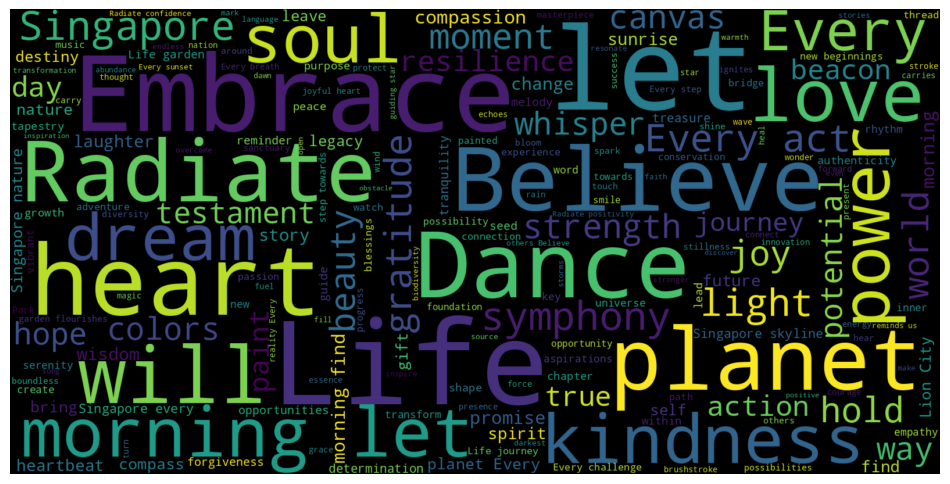

```python
# Use the wordcloud library to plot the wordcloud
wordcloud = WordCloud(width=1600, height=800, max_font_size=200).generate(' '.join(data))
plt.figure(figsize=(12,10))
sns.set_context('notebook',  font_scale=1.2)
sns.set_style('whitegrid', {'grid.color': '0.9'})

# Display the generated image
plt.imshow(wordcloud, interpolation='bilinear')
plt.axis("off")
plt.show()
```

**Observations**:

- We can see how the most common words are both a mix of starting words which are capitalized (e.g. Embrace, Dance, Life, Believe, Radiate) as well as other words in the quote (e.g. will, let, morning, heart, planet etc.)

Now, let's analyse the different common n-grams

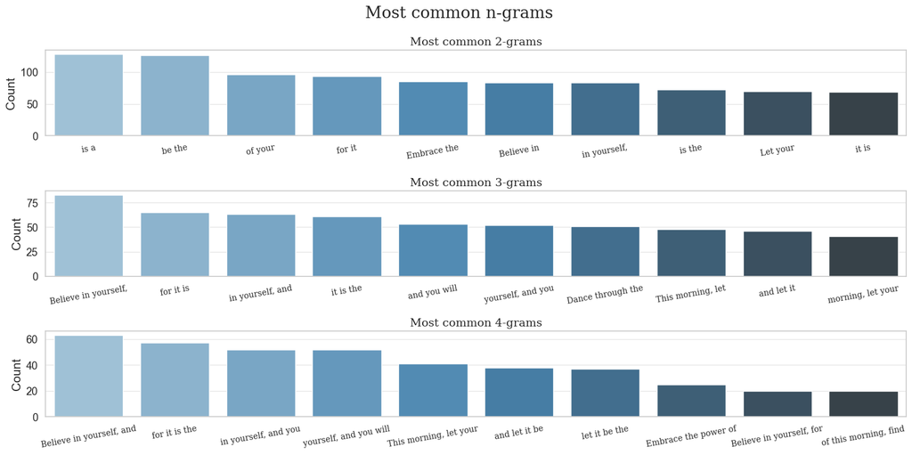

```python
# Do subplot of n-grams
from nltk import ngrams
from collections import Counter

fig, ax = plt.subplots(3, 1, figsize=(16, 8))

# Convert data to string
data_str = ' '.join(data)

grams_count = [2, 3, 4]

for i, gram in enumerate(grams_count):
    # Create n-grams
    n_grams = ngrams(data_str.split(), gram)
    n_grams_freq = Counter(n_grams)
    most_common_n_grams = n_grams_freq.most_common(10)

    # Convert keys of most_common_n_grams to string
    most_common_n_grams = list(map(lambda x: ' '.join(x[0]), most_common_n_grams))

    # Plot the most common n-grams
    sns.barplot(x=most_common_n_grams, y=list(map(lambda x: x[1], n_grams_freq.most_common(10))), ax=ax[i], palette='Blues_d', hue=most_common_n_grams)
    ax[i].set_xticks(range(10))
    ax[i].set_xticklabels(most_common_n_grams, rotation=10, fontfamily='serif', fontsize=10)
    ax[i].set_ylabel('Count', fontsize=15)
    ax[i].set_title(f"Most common {gram}-grams", fontfamily='serif', fontsize=14)

fig.suptitle("Most common n-grams", fontsize=20, fontfamily='serif')
plt.tight_layout()
plt.show()
```

**Observations**:

- For 2-gram, it shows that the top two most common 2-grams are "is a" and "be the". However, notice how it is very hard to spot these words inside the word cloud. This shows that the common 2-grams and 1-grams are actually quite different
- For the top three 4-grams, we can see how it is similar to the top three 3-grams with only addition of one extra word. This means that most phrases in the quotes are only similar up to 3-grams

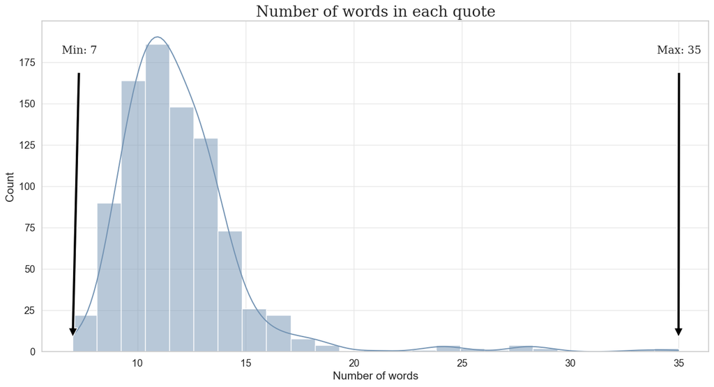

```python
# Plot a histogram of the number of words in each quote
fig, ax = plt.subplots(figsize=(16, 8))

# Convert data to string
data_str = [quote.split() for quote in data]

# Get the length of each quote
data_str = list(map(lambda x: len(x), data_str))

# Label min and max
ax.annotate(f"Min: {min(data_str)}", xy=(min(data_str), 0), xytext=(min(data_str)-0.5, 180), arrowprops=dict(facecolor='black', shrink=0.05), fontfamily='serif')
ax.annotate(f"Max: {max(data_str)}", xy=(max(data_str), 0), xytext=(max(data_str)-1, 180), arrowprops=dict(facecolor='black', shrink=0.05), fontfamily='serif')

# Plot the histogram
sns.histplot(data_str, ax=ax, color='#7393B3', bins=25, kde=True)

ax.set_xlabel("Number of words", fontsize=15)
ax.set_ylabel("Count", fontsize=15)
ax.set_title("Number of words in each quote", fontsize=20, fontfamily='serif')

plt.show()
```

**Observations**:

- The minimum number of quotes in the dataset is 7 and the maximum number of quotes is 35. This is important as it means that later on when generating input output pairs, we can only generate a maximum of uptil 7
- From the histogram, we can see that the distribution of the number of words is positively-skewed with the mode at around 11 quotes
- However, there are quite a lot of outliers with some quotes having more than 20 words

### **Feature Engineering**

First let us start off by tokenizing our words. We will be using Word Tokenization to Tokenize our text. In word tokenization, the data is split up into words and each unique word is tokenized with a unique index.

```python
# Tokenization

tokenizer = Tokenizer()
tokenizer.fit_on_texts(data)
print(tokenizer.word_index)
```

```
{'the': 1, 'of': 2, 'your': 3, 'and': 4, 'a': 5, 'is': 6, 'in': 7, 'for': 8, 'let': 9, 'to': 10, 'it': 11, 'be': 12, 'every': 13, 'our': 14, 'you': 15, 'that': 16, 'embrace': 17, "life's": 18, 'this': 19, 'are': 20, 'morning': 21, 'with': 22, 'radiate': 23, 'believe': 24, 'heart': 25, 'dance': 26, '…
```

```python
total_words = len(tokenizer.word_index) + 1
print(total_words)
```

```
1199
```

```python
for i in range(3):
    print(data[i])
    print(tokenizer.texts_to_sequences([data[i]])[0])
    print()
```

```
Believe in yourself, and let your heart lead the way.
[24, 7, 27, 4, 9, 3, 25, 186, 1, 55]

Believe in yourself, and let your light shine bright.
[24, 7, 27, 4, 9, 3, 48, 163, 486]

Believe in yourself, and let your spirit soar.
[24, 7, 27, 4, 9, 3, 69, 372]
```

##### Creating input-output pairings

For the generation of input-output pairings, we will be borrowing some concepts from time series, namely:

1. Expanding Window
2. Rolling Window (Sliding Window)

*Method 1*: **Expanding Window**

[figure not shown]

In expanding window, the window size changes with each prediction. So if the initial window size is n, the first prediction would use n days of data, the second prediction will use n+1 days of data and the $k^{th}$ day will use n+k days of data

*Method 2*: **Rolling Window**

[figure not shown]

For rolling window, the window size remains constant with each prediction but it shifts to the right by one. So if the initial window size is n, the first prediction would use data from [1, n], the second prediction will use data from [2, n+1] and the $k^{th}$ data will use data from [k, n+k-1]

Relevance to input output pair generation

Similar to how expanding window and rolling window are used in time series, we can use them to generate input output pairs since they are both sequences. In this case, the training data will be the input and the forecasted data will be the output. However, the forecasted data will only be forecasting one word into the future

E.g: Given the sequence "Who controls the past controls the future.", `Input` Output

**Expanding Window**

=> Using a window size of 1 (i.e. 1-gram)

Pass 1: `Who` controls the past controls the future.

Pass 2: `Who controls` the past controls the future.

Pass 3: `Who controls the` past controls the future.

Pass 4: `Who controls the past` controls the future.

and so on

after that, we can even go on and restart again but this time start from the second word

i.e.

Pass 1: Who `controls` the past controls the future.

Pass 2: Who `controls the` past controls the future.

Pass 3: Who `controls the past` controls the future.

etc. until we reach the very end

**Rolling Window**

=> Using a window size of n (i.e. n-gram)

For one gram,

Pass 1: `Who` controls the past controls the future.

Pass 2: Who `controls` the past controls the future.

Pass 3: Who controls `the` past controls the future.

Pass 4: Who controls the `past` controls the future.

For two gram,

Pass 1: `Who controls` the past controls the future.

Pass 2: Who `controls the` past controls the future.

Pass 3: Who controls `the past` controls the future.

Notice how when generating pairs with both methods simultaneously, we will inevitably end up with duplicated input output pairs

Using the Expanding Window Strategy

Using a nested for loop, we can generate input output pairs using the expanding window strategy

```python
expWin_input_output_pair = []

for datapoint in data:
    token_list = tokenizer.texts_to_sequences([datapoint])[0]
    for i in range(1, len(token_list)):
        for j in range(i+2, len(token_list)):
            expWin_input_output_pair.append(token_list[i:j])

print(f'Total number of quotes: {len(expWin_input_output_pair)}')
print(expWin_input_output_pair[:10])
```

```
Total number of quotes: 43501
[[7, 27], [7, 27, 4], [7, 27, 4, 9], [7, 27, 4, 9, 3], [7, 27, 4, 9, 3, 25], [7, 27, 4, 9, 3, 25, 186], [7, 27, 4, 9, 3, 25, 186, 1], [27, 4], [27, 4, 9], [27, 4, 9, 3]]
```

Using the Rolling Window Strategy

```python
# The following for-loop converts each of the quotes from texts to integers.

input_sequence = []

for datapoint in data:
    token_list = tokenizer.texts_to_sequences([datapoint])[0]
    input_sequence.append(token_list)

print(f'Total number of quotes: {len(input_sequence)}')
```

```
Total number of quotes: 890
```

```python
def create_ngrams(input_sequence=input_sequence, ngrams=2):
    n_grams = []
    for datapoint in input_sequence:
        for i in range(len(datapoint) - ngrams):
            n_grams.append(datapoint[i:i+ngrams])
    return n_grams
```

```python
rollWin_input_output_pairs = []
for i in range(2, 8):
    nth_pair = create_ngrams(ngrams=i)
    rollWin_input_output_pairs.extend(nth_pair)
    print(f'Total number of {i}-grams: {len(nth_pair)}')
    print(f'First {i}-gram: {nth_pair[:5]}')
    print()
```

```
Total number of 2-grams: 8839
First 2-gram: [[24, 7], [7, 27], [27, 4], [4, 9], [9, 3]]

Total number of 3-grams: 7949
First 3-gram: [[24, 7, 27], [7, 27, 4], [27, 4, 9], [4, 9, 3], [9, 3, 25]]

Total number of 4-grams: 7059
First 4-gram: [[24, 7, 27, 4], [7, 27, 4, 9], [27, 4, 9, 3], [4, 9, 3, 25], [9, 3, 25, 186]]

Total number of 5-grams: 6169
First 5-gram: [[24, 7, 27, 4, 9], [7, 27, 4, 9, 3], [27, 4, 9, 3, 25], [4, 9, 3, 25, 186], [9, 3, 25, 186, 1]]

Total number of 6-grams: 5279
First 6-gram: [[24, 7, 27, 4, 9, 3], [7, 27, 4, 9, 3, 25], [27, 4, 9, 3, 25, 186], [4, 9, 3, 25, 186, 1], [24, 7, 27, 4, 9, 3]]

Total number of 7-grams: 4389
First 7-gram: [[24, 7, 27, 4, 9, 3, 25], [7, 27, 4, 9, 3, 25, 186], [27, 4, 9, 3, 25, 186, 1], [24, 7, 27, 4, 9, 3, 48], [7, 27, 4, 9, 3, 48, 163]]
```

```python
# We can similarly build input-output pairs where the input has N-1 words.
# The input is say, every N-1 words and the corresponding output is the last word.
# So, let us create a list of "N words", i.e. the entire quote.

input_output_pairN = []
for datapoint in input_sequence:
    input_output_pairN.append(datapoint) # Why no nested for-loop?

print(f'Total number of input-output pairs is: {len(input_output_pairN)}')
```

```
Total number of input-output pairs is: 890
```

```python
# Let us combine our sequences of different lengths by padding them so that all have the same length,
# and then converting to a numpy array.

input_output_pairs = expWin_input_output_pair + input_output_pairN
input_output_pairs.extend(rollWin_input_output_pairs)

max_sequence_len = max([len(x) for x in input_output_pairs])

print(len(input_output_pairs))

input_output_pairs = np.array(pad_sequences(input_output_pairs, maxlen=max_sequence_len, padding='pre'))
print(len(input_output_pairs))
print(input_output_pairs)
```

```
84075
84075
[[  0   0   0 ...   0   7  27]
 [  0   0   0 ...   7  27   4]
 [  0   0   0 ...  27   4   9]
 ...
 [  0   0   0 ... 602   2   3]
 [  0   0   0 ...   2   3  25]
 [  0   0   0 ...   3  25  19]]
```

```python
# Now that we have an array, let us slice the last word as the output.
# The preceding words are the input.

X = input_output_pairs[:,:-1]
y = input_output_pairs[:,-1]
print(X)
print(y)
```

```
[[  0   0   0 ...   0   0   7]
 [  0   0   0 ...   0   7  27]
 [  0   0   0 ...   7  27   4]
 ...
 [  0   0   0 ...  13 602   2]
 [  0   0   0 ... 602   2   3]
 [  0   0   0 ...   2   3  25]]
[27  4  9 ...  3 25 19]
```

```python
# Shuffle the dataset
X, y = shuffle(X, y, random_state=42)
```

```python
# Let us convert y to be a one-hot array.

y = utils.to_categorical(y, num_classes=total_words)
print(y)
```

```
[[0. 0. 0. ... 0. 0. 0.]
 [0. 0. 0. ... 0. 0. 0.]
 [0. 0. 0. ... 0. 0. 0.]
 ...
 [0. 0. 0. ... 0. 0. 0.]
 [0. 0. 0. ... 0. 0. 0.]
 [0. 0. 1. ... 0. 0. 0.]]
```

```python
print(total_words)
print(X.shape)
print(y.shape)
```

```
1199
(84075, 34)
(84075, 1199)
```

When splitting the X and y dataset, we will not be using X_test and y_test since we will be evaluating the model using the seed texts and how well it predicts the texts. As such, we will only be splitting into test and validation

```python
# Split the data into training and testing sets.
X_train, X_val, y_train, y_val = train_test_split(X, y, test_size=0.2)

print("X_train shape:", X_train.shape)
print("X_val shape:", X_val.shape)
```

```
X_train shape: (67260, 34)
X_val shape: (16815, 34)
```

```python
# Combine them into a tensorflow dataset.
train_ds = tf.data.Dataset.from_tensor_slices((X_train, y_train))
val_ds = tf.data.Dataset.from_tensor_slices((X_val, y_val))
```

### **Model Training**

##### Baseline Model (Vanilla RNN)

RNN Layers Explained

Let us start off by building a vanilla RNN model. RNNs (Recurrent neural networks), are used to handle the shortcomings that feedfoward neural networks have when dealing with sequetial data

The pros and cons of a Vanilla RNN compared to a Feed Foward Network is summed up below:

| Advantages | Disadvantages |
| --- | --- |
| Possibility of processing input of any length | Computation is much slower |
| Computation takes into account historical information | Difficult to access information from a long time ago |

[figure not shown]

*Figure: Feed Forward Network vs RNN*

Unlike how Feed Forward Networks are unidirectional, RNN's has loops inside it to persist information over the sequence. $h_t$ is the hidden state of the input at time $t$.

During every forward propagation, there is a recurrence relation applied where the current hidden state is calculated based on the previous hidden state and the input at the current through $h_t = f_w(W_{hh}^{t}h_{t-1} + W_{xh}^{t}X_{t})$ where $f_w$ is a non-linear function like $tanh$. The hidden state can be considered the "memory" of the network

At evey cell, $\hat{y_t}$ denotes the output at step $t$ and it can be calculated using the current hidden state $\hat{y_t} = softmax(W_{hy}^{t}h_t)$

Note that when calculating the current hidden state, tanh is used and when calculating the output, softmax is used. This is because relu is usually avoided (unless gradient clipping is used) due to the exploding gradient problem and a non-linear function is needed to calculate the current hidden state so tanh is used to calculate the the current hidden state to resize the input values to the range of [-1, 1]. Howver, when trying to convert the raw output scores into a probability distribution, softmax has to be used which is why it is used to calculate the output

[figure not shown]

*Figure: Image of a single Vanilla RNN Cell*

Vanilla RNN Baseline Model Architecture

Optimizer: Adam Epochs: 30

```python
# Input is max sequence length - 1, as we've removed the last word for the label.
input_len = max_sequence_len - 1

RNN_model = Sequential(
    name='VanillaRNN_model',
    layers=[
        Embedding(total_words, 100, input_length=input_len),
        SimpleRNN(64, activation = 'tanh', dropout=0.3),
        Dense(total_words, activation='softmax')
    ]
)

RNN_model.summary()

RNN_model.compile(loss='categorical_crossentropy', optimizer=Adam(learning_rate=0.005), metrics=['accuracy'])

# Train the model.
RNN_history = RNN_model.fit(train_ds.batch(64), validation_data=val_ds.batch(64), epochs=30, verbose=1)
```

[output not shown]

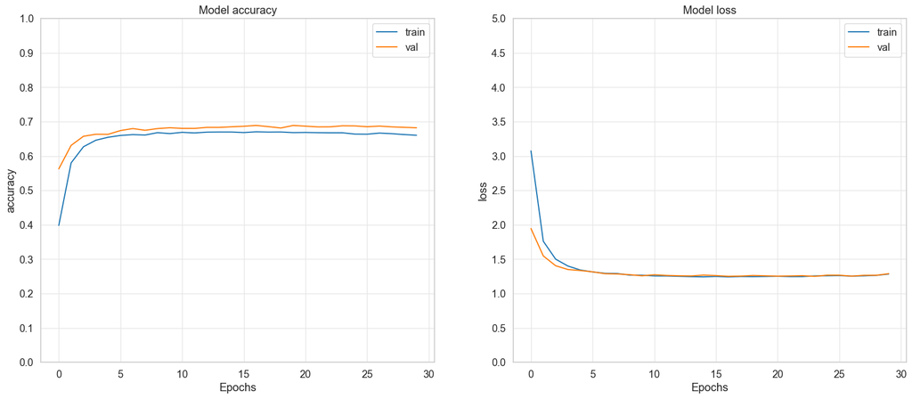

```python
plot_history(RNN_history, 30)
```

**Observations**:

Let us look at how well our model can predict words given a few seed texts

```python
def predict_next_N_words(input_text, N=10, model=RNN_model):
    for _ in range(N):
        # Tokenize the input text
        token_list = tokenizer.texts_to_sequences([input_text])[0]
        # Pad the input text
        token_list = pad_sequences([token_list], maxlen=max_sequence_len-1, padding='pre')
        # Predict the next word
        predicted_prob = model.predict(token_list, verbose=0)[0]
        chosen_word_index = np.argmax(predicted_prob)
        # Convert the predicted word to text
        predicted_word = tokenizer.index_word[chosen_word_index]
        input_text += " " + predicted_word
    return input_text
```

```python
seed_texts = [
    "embrace each day",
    "radiate some",
    "believe that",
    "life's actual purpose is",
    "dance through each and every",
    "let your time and energy",
    "every person is",
    "our country Singapore is",
    "planet earth is",
    "morning and evening would make it",
]

for seed_text in seed_texts:
    print(predict_next_N_words(seed_text, N=10, model=RNN_model))
    print()
```

```
embrace each day with the stories of our true calling and potential within

radiate some confidence for it is the truest expression of your truest

believe that ignites positivity and light shine for it is the truest

life's actual purpose is a step towards the tranquility the tranquility around you towards

dance through each and every day is a canvas for new beginnings reminding us of

let your time and energy will leave a legacy of love for it is the

every person is a testament to the beauty of our planet's wild spirit

our country Singapore is a step towards the tranquility of the heart a serene

planet earth is a harmonious canvas paint it with intention and love you

morning and evening would make it is the truest expression of your truest and most beautiful
```

**Observations**:

- We can see that most of the generated texts are not very good so there are still some improvements to be made

##### LSTM and GRU

In order to remedy the vanishing gradient problem, specific gates are used in some types of RNNs with each gate having a well-defined purpose. They can be combuted using $\Gamma = \sigma(Wx^{t} + Uh^{t-1} + b)$, where $W$, $U$ and $b$ are coefficients specific to the gate and $\sigma$ is the sigmoid function. The main gates are:

| Type of gate | Role | Used In |
| --- | --- | --- |
| Update gate $\Gamma_{u}$ | How much past should matter now? | GRU, LSTM |
| Relevance gate $\Gamma_{r}$ | Drop previous information? | GRU, LSTM |
| Forget gate $\Gamma_{f}$ | Erase a cell or not? | LSTM |
| Output gate $\Gamma_{o}$ | How much to reveal of a cell? | LSTM |

Gated Recurrent Unit (GRU)

[figure not shown]

*Figure: Image of GRU Cell*

A GRU has two gates, a reset gate $\Gamma_{r}$ and an update gate $\Gamma_{u}$

The reset gate determines how to combine the new input with the previous memory and update gates defines how much of the previous memory to keep around

```python
# Input is max sequence length - 1, as we've removed the last word for the label.
input_len = max_sequence_len - 1

GRU_model = Sequential(
    name='GRU_model',
    layers=[
        Embedding(total_words, 100, input_length=input_len),
        GRU(128, activation = 'tanh', dropout=0.3, recurrent_regularizer=l2(0.001)),
        Dense(total_words, activation='softmax')
    ]
)

GRU_model.summary()

GRU_model.compile(loss='categorical_crossentropy', optimizer=Adam(learning_rate=0.005), metrics=['accuracy'])

# Train the model.
GRU_history = GRU_model.fit(train_ds.batch(64), validation_data=val_ds.batch(64), epochs=30, verbose=1)
```

[output not shown]

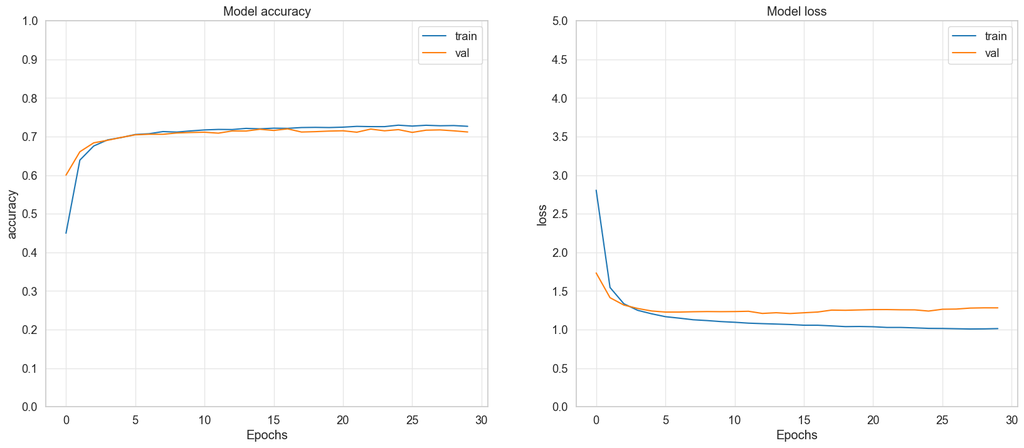

```python
plot_history(GRU_history, 30)
```

**Observations**:

- We can see that the model is still underfitting
- However, the accuracy has actually improved with an accuracy of around 70% now and the loss has also decreased

Long Short Term Memory (LSTM)

[figure not shown]

*Figure: Image of LSTM Cell*

The idea behind a LSTM layer is quite similar to a GRU layer. However, LSTM has more gates than GRU and can typically capture longer dependencies compared to GRU.

LSTM also introduces the concept of a memory cell $C_{i}$ (a numerical vector of pre-defined size) which is updated each time a new input is supplied

It also has two additional gates, the forget gate $\Gamma_{f}$ which is used to control how much past memory is kept from the previous hidden state $h_{t-1}$ and the current input $X_t$ and the output gate $\Gamma_{o}$ which is used to update the hidden state

```python
# Input is max sequence length - 1, as we've removed the last word for the label
from tensorflow.keras.layers import BatchNormalization
input_len = max_sequence_len - 1

LSTM_model = Sequential(
    name='LSTM_model',
    layers=[
        Embedding(total_words, 100, input_length=input_len),
        LSTM(128, activation = 'tanh', dropout=0.3, recurrent_regularizer=l2(0.001)),
        Dense(total_words, activation='softmax')
    ]
)

LSTM_model.summary()

LSTM_model.compile(loss='categorical_crossentropy', optimizer=Adam(learning_rate=0.005), metrics=['accuracy'])

# Train the model
LSTM_history = LSTM_model.fit(train_ds.batch(64), validation_data=val_ds.batch(64), epochs=30, verbose=1)
```

[output not shown]

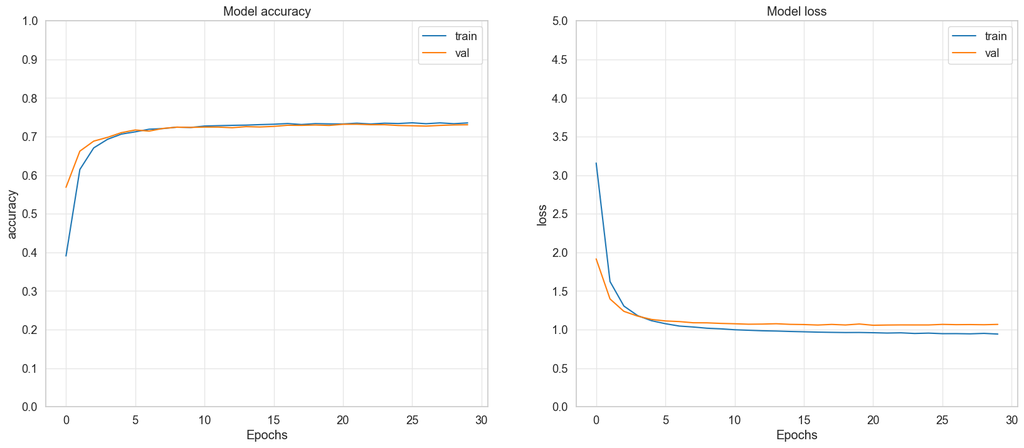

```python
plot_history(LSTM_history, 30)
```

**Observations**:

- We can see that LSTM has a slightly higher accuracy compared to GRU and a validation loss of consistenly below 1.5
- However, accuracy and loss are not the best evaluation metrics when it comes to text generation so let's manually take a look at how well the model predicts text

Temperature

Let us now compare the difference in text prediction for LSTM and GRU

Notice how previously, our implementation of predict_next_N_words would always give the same results when given the same seed texts. In order to make our model capable of producing different sequences of output texts given the same input, we can introduce a new parameter called temperature

Temperature is often used to control the randomness of the output distribution. Typically a higher temperature increases the amount of randomness which can lead to more diverse outputs while a lower temperature decreases the amount of randomness which leads to more deterministic outputs. Temperature is often used to adjust the distribution of probabilities generated by the softmax function and can be calculated as follows

$$\sigma(z_{i}) = \frac{e^{\frac{z_{i}}{T}}}{\Sigma_{k=0}^{N}e^{\frac{z_{k}}{T}}}$$

In summary, higher temperatures make the model more "creative" while lower temperatures can make the model more confident and provide more "meaningful" answers

```python
def predict_next_N_words(input_text, N=10, temperature=0.1, model=RNN_model):
    for _ in range(N):
        # Tokenize the input text
        token_list = tokenizer.texts_to_sequences([input_text])[0]
        # Pad the input text
        token_list = pad_sequences([token_list], maxlen=max_sequence_len-1, padding='pre')
        # Predict the next word
        predicted_prob = model.predict(token_list, verbose=0)[0]
        # Apply temperature
        predicted_prob = np.array(predicted_prob)**(1/temperature)
        predicted_prob = predicted_prob / np.sum(predicted_prob)
        chosen_word_index = np.random.choice(len(predicted_prob), p=predicted_prob)
        # Convert the predicted word to text
        predicted_word = tokenizer.index_word[chosen_word_index]
        input_text += " " + predicted_word
    return input_text
```

Let's take a look at the effect of temperatures when using the same seed_texts

```python
for i in range(3):
    print(predict_next_N_words("life's actual purpose is", N=10, temperature=0.5, model=LSTM_model))
```

```
life's actual purpose is a tribute to the boundless power of the heart to
life's actual purpose is a tribute to the boundless power of the heart to
life's actual purpose is a tribute to the boundless power of the heart to
```

**Observations**:

```python
# Predict the next 10 words given the seed text
seed_texts = [
    "embrace each day",
    "radiate some",
    "believe that",
    "life's actual purpose is",
    "dance through each and every",
    "let your time and energy",
    "every person is",
    "our country Singapore is",
    "planet earth is",
    "morning and evening would make it",
]

print("GRU")
for seed_text in seed_texts:
    print(predict_next_N_words(seed_text, N=10, temperature=0.3, model=GRU_model))
    print()

print("LSTM")
for seed_text in seed_texts:
    print(predict_next_N_words(seed_text, N=10, temperature=0.3, model=LSTM_model))
    print()
```

```
GRU
embrace each day brings new opportunities to discover your true potential and possibilities

radiate some humility for it is the mark of a truly great

believe that in yourself and you will find your way for the

life's actual purpose is a pledge to tread lightly on our planet holds the

dance through each and every moment into a gift from the universe a reminder of

let your time and energy it radiates from your heart to the soul of our

every person is a step towards a contented heart in the heart of

our country Singapore is where cultures intertwine creating a tapestry of joy and world

planet earth is a precious jewel in the cosmos deserves our utmost care

morning and evening would make it turns even the smallest gifts into treasures treasures you treasures

LSTM
embrace each day with a canvas for new beginnings reminding us of the

radiate some compassion for it is the language of the soul a

believe that truly great soul you can give to another waterway's vibrancy

life's actual purpose is a tribute to the boundless power of the heart to

dance through each and every sunset whispers promises of tomorrow's beauty with breathe life into

let your time and energy it radiates from your heart to the boundless power the

every person is a step towards the tranquility of the heart a serene

our country Singapore is alive and thriving thriving actions offers the promise of a

planet earth is a precious gift you can give to another in the

morning and evening would make it holds the promise of new beginnings and fresh start and
```

**Observations**:

##### Bidirectional Models

[figure not shown]

*Figure: Image of an Bidirectional Model*

Bidirectional models are architectures that process data in both forward and backward directions which allows the model to capture information from the past and the future context of each input which is useful in tasks where understanding context is important.

Bidirectional LTSM

Instead of using a unidirectional LSTM, we could use a Bidirectional wrapper around the LSTM layer which processes the input sequence in both the forward and backward directions creating two sets of hidden states: one capturing informatino from the past and the other from the future.

```python
# Bidirectional LSTM

# Input is max sequence length - 1, as we've removed the last word for the label.
input_len = max_sequence_len - 1

BiLSTM_model = Sequential(
    name='Bidirectional_LSTM_model',
    layers=[
        Embedding(total_words, 100, input_length=input_len),
        Bidirectional(LSTM(128, activation = 'tanh')),
        Dense(total_words, activation='softmax')
    ]
)

BiLSTM_model.summary()

BiLSTM_model.compile(loss='categorical_crossentropy', optimizer=Adam(learning_rate=0.005), metrics=['accuracy'])

# Train the model.
BiLSTM_history = BiLSTM_model.fit(train_ds.batch(64), validation_data=val_ds.batch(64), epochs=30, verbose=1)
```

[output not shown]

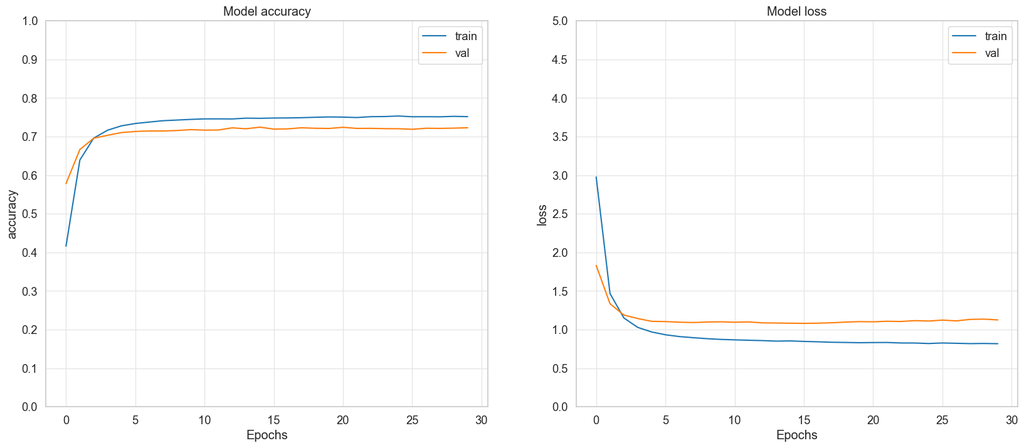

```python
plot_history(BiLSTM_history, 30)
```

**Observations**:

- The performance of the model not only did not improve but is also slightly worse compared to the unidirectional LSTM in terms of accuracy and loss
- This is likely because of short sequence length in the dataset so bidirectional processing may not provide a significant advantage as bidirectional LSTMs often show more benefit on longer sequences where information from both ends can be useful
- However, we can should still test the output of this model

Decoding Methods

So far, we have only been using the greedy method for decoding, however, there are many other methods such as:

- Beam Search
- K-sampling
- Neucleus-sampling

We will be using a few of them to try and make our model text output more creative

Greedy Search

So far, the only method we have been using is greedy search.

Greedy search selects from the language model the word with the highest probability as the next word.

[figure not shown]

*Figure: Greedy Search diagram*

Suppose the language model is predicting a possible continuation to a sentence starting with "The", then by using greedy search, the model will always choose the word with the highest probability which in this case, is "cat". In our implementation of predict_next_N_words, we used temperature to introduce some randomness to greedy search. However, there are other alternatives to try and get different texts or more creative outputs

Top-K-Sampling

In Top-K sampling, the top K words with the highest words are filtered and then the next predicted word will be randomly sampled among these K words. The produced text from Top-K sampling can be more human-sounding than the text produced with Greedy Search. However, one concern with Top-K sampling is that it does not dynamically adapt the number of words that are filtered as K is fixed. As a consequence, very unlikely words may be selected among these K words if the next word probability distribution is very sharp

Nucleus (Top-p) sampling

Nucleus sampling chooses from the smallest possible set of words whose cumulative probability exceeds the probability p. THis way, the number of words in the set can dynamically increase and decrease according to the next word probability distribution

```python
def greedy(input_text, temperature=0.1, N=10, model=RNN_model):
    log_likelihood = 0
    for _ in range(N):
        # Tokenize the input text
        token_list = tokenizer.texts_to_sequences([input_text])[0]
        # Pad the input text
        token_list = pad_sequences([token_list], maxlen=max_sequence_len-1, padding='pre')
        # Predict the next word
        predicted_prob = model.predict(token_list, verbose=0)[0]
        np.seterr(divide = 'ignore')
        predictions = np.log(predicted_prob) / (temperature)
        np.seterr(divide = 'warn')
        exp_predictions = np.exp(predictions)
        predicted_probs = exp_predictions / np.sum(exp_predictions)
        chosen_word_index = np.random.choice(range(len(predicted_probs)), p=predicted_probs)
        # Convert the predicted word to text
        predicted_word = tokenizer.index_word[chosen_word_index]
        input_text += " " + predicted_word
        log_likelihood += np.log2(predicted_prob[chosen_word_index])
    return input_text, log_likelihood
```

```python
def k_sampling(input_text, k=75, temperature=0.1, N=10, model=RNN_model):
    log_likelihood = 0
    for _ in range(N):
        # Tokenize the input text
        token_list = tokenizer.texts_to_sequences([input_text])[0]
        # Pad the input text
        token_list = pad_sequences([token_list], maxlen=max_sequence_len-1, padding='pre')
        # Predict the next word
        predicted_prob = model.predict(token_list, verbose=0)[0]
        predicted_prob = np.array(predicted_prob)
        # Reduce those not in top k to 0 (i.e. filter out those not in top k)
        predicted_prob[np.argsort(predicted_prob)[:-k]] = 0
        np.seterr(divide = 'ignore')
        predictions = np.log(predicted_prob) / temperature
        np.seterr(divide = 'warn')
        exp_predictions = np.exp(predictions)
        predicted_probs = exp_predictions / np.sum(exp_predictions)
        # Random sample from top k
        chosen_word_index = np.random.choice(range(len(predicted_probs)), p=predicted_probs)
        # Convert the predicted word to text
        predicted_word = tokenizer.index_word[chosen_word_index]
        input_text += " " + predicted_word
        log_likelihood += np.log2(predicted_prob[chosen_word_index])
    return input_text, log_likelihood
```

```python
# Predict the nucleus top p sampling
def nucleus_sampling(input_text, p=0.5, temperature=0.1, N=10, model=RNN_model):
    log_likelihood = 0
    for _ in range(N):
        # Tokenize the input text
        token_list = tokenizer.texts_to_sequences([input_text])[0]
        # Pad the input text
        token_list = pad_sequences([token_list], maxlen=max_sequence_len-1, padding='pre')
        # Predict the next word
        predicted_prob = model.predict(token_list, verbose=0)[0]
        predicted_prob = np.array(predicted_prob)
        # Reduce those not in top p to 0 (i.e. filter out those not in top p)
        sorted_probs = np.sort(predicted_prob)
        sorted_probs = sorted_probs[::-1]
        sorted_probs = sorted_probs.cumsum()
        sorted_probs /= sorted_probs[-1]
        # Get indices of those in top p
        indices = np.arange(len(sorted_probs))
        selected_indices = indices[sorted_probs <= p]
        # Reduce those not in top p to 0
        predicted_prob[selected_indices] = 0
        np.seterr(divide = 'ignore')
        predictions = np.log(predicted_prob) / temperature
        np.seterr(divide = 'warn')
        exp_predictions = np.exp(predictions)
        predicted_probs = exp_predictions / np.sum(exp_predictions)
        # Random sample from top p
        chosen_word_index = np.random.choice(range(len(predicted_probs)), p=predicted_probs)
        # Convert the predicted word to text
        predicted_word = tokenizer.index_word[chosen_word_index]
        input_text += " " + predicted_word
        log_likelihood += np.log2(predicted_prob[chosen_word_index])
    return input_text, log_likelihood
```

Now, let us try predict some texts using the different decoding methods

```python
decoders = [greedy, k_sampling, nucleus_sampling]

for decoder in decoders:
    print(decoder.__name__.capitalize())
    for i, text in enumerate(seed_texts):
        prediction, loss = decoder(text, temperature=0.3, model=BiLSTM_model)
        print(prediction)
        print()
    print()
```

```
Greedy
embrace each day with a heart full of gratitude for it is the

radiate some love for it is the truest expression of your being

believe that this morning presents to the goodness in your heart and

life's actual purpose is an opportunity for growth and wisdom that reside within you

dance through each and every sunrise is a canvas for new beginnings and fresh moments

let your time and energy that propels you to your dreams be the driving force

every person is rich and the vision of life on the opportunities that

our country Singapore is a pledge to tread lightly on our planet and contentment

planet earth is a treasure in the chest of memories a new day

morning and evening would make it knows no bounds into is a treasure trove the uncovered


K_sampling
embrace each day with a heart full of gratitude for it is the

radiate some confidence and let it be the foundation of your strength

believe that this morning presents to the goodness in your heart and

life's actual purpose is an opportunity for growth and let it light up the

dance through each and every sunrise is a canvas for new beginnings and fresh moments

let your time and energy that propels you to your dreams be the foundation of

every person is rich and the vision of life for our planet's beauty

our country Singapore is a pledge to tread lightly on our planet and contentment

planet earth is a treasure in the chest of memories a new day
```

[output cut: 9 more lines]

```
believe that this morning presents to the goodness in your heart and

life's actual purpose is an opportunity for growth and let your heart be the

dance through each and every sunrise is a canvas for new beginnings and fresh moments

let your time and energy that propels you to your dreams is an investment in

every person is rich and the vision of life and the gentle goodbyes

our country Singapore is a gift a reminder of the marvel the marvel of

planet earth is a gift to the soul of our planet a nation's

morning and evening would make it knows no bounds into a stronger wiser and more resilient
```

**Observations**:

- We can see that despite using different decoding meethods, some predicted texts like "embrace each day ..." still remain the same
- Overall, it seems that the text quality for the bidirectional LSTM slightly worse compared to LSTM and GRU with certain sentences making no sense

##### Attention layer

Attention mechanisms enhance deep learning models by selectively focusing on important input elements which improves prediction accuracy. They emphasize on relevant information acting as a spotlight to enhance overall model performance

The attention mechanism works by assigning a weight to each part of the input sequence. The model then uses these weights to calculate a weighted sum of the input sequence which is used to generate the output sequence. The parts of the input sequence which are more important are given higher weights so they have a greater influence on the output sequence

Since our LSTM Model did seem to perform better compared to the Bi-directional LSTM model, we wll be using LSTM instead of Bi-directional LSTM for our model with attention

```python
# Attention is all you need

# Input is max sequence length - 1, as we've removed the last word for the label.
input_len = max_sequence_len - 1

inputs = Input(shape=(input_len,))
embedding_layer = Embedding(total_words, 100, input_length=input_len)(inputs)
attention_in = LSTM(256, return_sequences=True, recurrent_regularizer=l2(0.001), dropout=0.3)(embedding_layer)

# Add attention
attention = Attention(use_scale=True)([attention_in, attention_in])
# Return last output instead of entire sequence
outputs = TimeDistributed(Dense(total_words, activation='softmax'))(attention)
reshape_outputs = Lambda(lambda x: x[:, -1, :])(outputs)


LSTMAttention_model = Model(inputs, reshape_outputs, name='LSTMAttention_model')

LSTMAttention_model.summary()

LSTMAttention_model.compile(loss='categorical_crossentropy', optimizer=Adam(learning_rate=0.005), metrics=['accuracy'])

# Train the model.
LSTMAttention_history = LSTMAttention_model.fit(train_ds.batch(64), validation_data=val_ds.batch(64), epochs=30, verbose=1)
```

[output not shown]

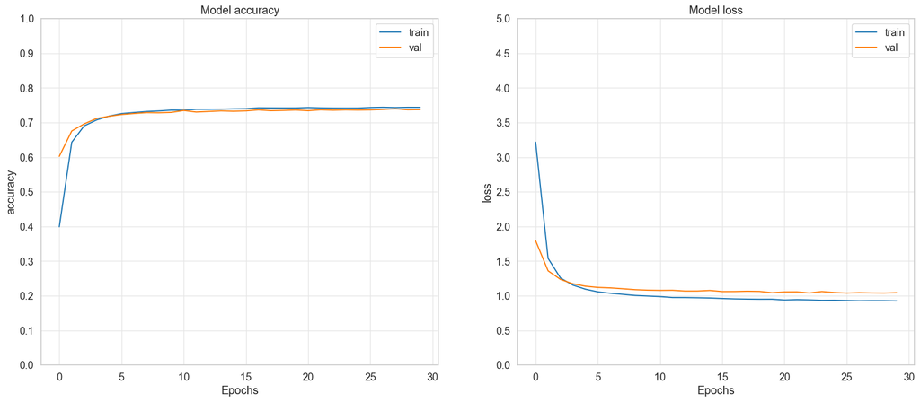

```python
plot_history(LSTMAttention_history, 30)
```

**Observations**:

- From the graph, we can see that the accuracy with the attention mechanism is better compared to the bidirectional LSTM
- However, it seems that the accuracy cannot pass a certain threshold because it seems that there are no longer any more features that can be extracted by the model

Previously, we have always been manually trying to evaluate the text generated from our model. However, it is quite obvious that manually evaluating text is quite subjective as it is not a process with pre-defined steps. In addition, it can also start to become time-consuming if our seed_texts becomes longer.

As such, we can go ahead and use some of the common metrics use to evaluate text generation to try and provide a more objective and quantifiable measure for the model's performance

1. Bleu Score

Bleu Score, which stands for Bilingual Evaluation Understudy Score, is a metric used for evaluating a generated sentence compared to a reference sentence. It calculates the n-gram overlap of the reference and generated texts. The score is calculated using the geometric mean of the precision for n-grams in the generated text that match with the reference text such that more overlaps will result in a higher Bleu Score. The score ranges from [0, 1] with 1 being the best possible score

2. Perplexity

Perplexity is a measure of how well a probability model predicts a sample. In the context of Natural Language Processing (NLP), it is used as a measure of probability for a sentence to be produced by the model trained on a dataset.

The perplexity of a discrete probability distribution is defined as: $$ Perplexity = 2^{H(p)} = 2^{-\Sigma_{x}p(x)log_{2}p(x)}$$

where H(p) is the entropy of the distribution p(x) and x is a random variable over all possible events

We can futher simplify the equation as follows:

$$ \begin{align} Perplexity &= 2^{-\Sigma_{x}^{N}p(x)log_{2}q(x)} \nonumber \\ &= 2^{-\Sigma_{x}^{N}\frac{1}{N}log_{2}q(x)} \text{(assuming all words have the same frequency)} \nonumber \\ \end{align} $$

where p is the probability distribution that we want to model and q is our proposed probability model (i.e. our prediction) By using q and testing it against samples drawn from p, we are basically calculating the cross-entropy so we can use the probability array generated when predicting the next word and use it for q(x) to manually calculate perplexity

[figure not shown]

*Figure: Image of perplexity calculation*

```python
# Used for evaluation of the model
from nltk.translate.bleu_score import corpus_bleu, SmoothingFunction

# Smoothing function made by chencherry
chencherry = SmoothingFunction()

def evaluate_bleu(references, text):

    candidate = ["".join([text]).split(" ")]

    score = corpus_bleu(references, candidate, weights=(0.1, 0.2, 0.3, 0.4), smoothing_function=chencherry.method1)
    return score
```

```python
def evaluate_perplexity(log_likelihood, num_words):

    perplexity = 2**(-log_likelihood / num_words)

    return perplexity
```

```python
# Get all the quotes out with the following structure similar to seed_texts
import re
def getReferences(refType='all'):
    refHeader = ['Embrace', 'Radiate', 'Believe in yourself', "Life's", "Dance through", "Let your", "Every", "Singapore" ,"Our planet", "This morning, let"]

    # Used to filter out and only get specific quotes
    if type(refType) == int and 0 <= refType < len(refHeader):
        refHeader = [refHeader[refType]]
    # Invalid refType
    elif refType != 'all':
        print("Invalid refType")
        return

    ref = []
    for quote in data:
        for substring in refHeader:
            if (substring in quote):
                ref += [re.sub('[,;.]', '', quote).split(" ")]

    return [ref]
```

```python
decoders = [greedy, k_sampling, nucleus_sampling]

for decoder in decoders:
    print(decoder.__name__.capitalize())
    for i, text in enumerate(seed_texts):
        references = getReferences('all')
        prediction, loss = decoder(text, temperature=0.3, model=LSTMAttention_model)
        print(prediction)
        print(f"BLEU Score: {evaluate_bleu(references, prediction)}")
        print(f"Perplexity: {evaluate_perplexity(loss, len(prediction.split(' ')))}")
        print()
    print()
```

```
Greedy
embrace each day brings new opportunities to discover our inner strength and innovation
BLEU Score: 0.8022993698822215
Perplexity: 1.012909258352056

radiate some forgiveness and let it be the balm that heals old
BLEU Score: 0.8054903041477958
Perplexity: 1.0343273606969512

believe that guides you to your strength and let it be the
BLEU Score: 0.7253363741970279
Perplexity: 1.0375156176664952

life's actual purpose is an opportunity for growth and enlightenment enlightenment will let your
BLEU Score: 0.4464160583563588
Perplexity: 1.0364450277086639

dance through each and every act of conservation is a legacy of love for our
BLEU Score: 0.6639932093829113
Perplexity: 1.0247342177890175

let your time and energy up the universe will conspire in your favor to the
BLEU Score: 0.4428762472995024
Perplexity: 1.0260059819627987

every person is a brighter when we spread kindness and joy will follow
BLEU Score: 0.6380627024873906
Perplexity: 1.0238443894875955

our country Singapore is a canvas for new beginnings reminding us of the preciousness
BLEU Score: 0.4316354214148323
Perplexity: 1.0212243458273222

planet earth is a precious jewel in the cosmos deserves our utmost care
BLEU Score: 0.753764963520823
Perplexity: 1.000341464225251

morning and evening would make it sing its own song of our planet a precious jewel
BLEU Score: 0.38433433172963083
Perplexity: 1.0087629697744795
```

[output cut: 69 more lines]

```
every person is a brighter when we spread kindness and joy will follow
BLEU Score: 0.6380627024873906
Perplexity: 1.0238443894875955

our country Singapore is a bridge between hearts and restore faith our time etched
BLEU Score: 0.4119446945262224
Perplexity: 1.0380686067785778

planet earth is a precious jewel in the cosmos deserves our utmost care
BLEU Score: 0.753764963520823
Perplexity: 1.000341464225251

morning and evening would make it sing its own song of our planet a precious jewel
BLEU Score: 0.38433433172963083
Perplexity: 1.0087629697744795
```

### **Model Evaluation**

Let us now evaluate all the models we have trained so far and get their mean BLEU scores, loss and perplexity.

```python
eval_df = pd.DataFrame(columns=['Model', 'Mean Greedy BLEU', 'Mean Greedy Perplexity', 'Mean K-Sampling BLEU', 'Mean K-Sampling Perplexity', 'Mean Nucleus Sampling BLEU', 'Mean Nucleus Sampling Perplexity'])
models = [RNN_model, GRU_model, LSTM_model, BiLSTM_model, LSTMAttention_model]
decoders = [greedy, k_sampling, nucleus_sampling]

for model in models:
    model_eval = []
    for decoder in decoders:
        bleu = 0
        perplexity = 0
        for i, text in enumerate(seed_texts):
            references = getReferences('all')
            prediction, loss = decoder(text, temperature=0.3, model=model)
            bleu += evaluate_bleu(references, prediction)
            perplexity += evaluate_perplexity(loss, len(prediction.split(" ")))
        avg_bleu = bleu/len(seed_texts)
        avg_perplexity = perplexity/len(seed_texts)
        # Add to list
        model_eval += [avg_bleu, avg_perplexity]
    # Add to eval_df
    eval_df.loc[len(eval_df)] = [model.name] + model_eval

display(eval_df)
```

|  | Model | Mean Greedy BLEU | Mean Greedy Perplexity | Mean K-Sampling BLEU | Mean K-Sampling Perplexity | Mean Nucleus Sampling BLEU | Mean Nucleus Sampling Perplexity |
| --- | --- | --- | --- | --- | --- | --- | --- |
| 0 | VanillaRNN_model | 0.534351 | 1.503569 | 0.569361 | 1.479820 | 0.625668 | 1.464647 |
| 1 | GRU_model | 0.570121 | 1.205671 | 0.563787 | 1.194119 | 0.547061 | 1.212954 |
| 2 | LSTM_model | 0.562975 | 1.223874 | 0.534037 | 1.226602 | 0.577938 | 1.180749 |
| 3 | Bidirectional_LSTM_model | 0.570104 | 1.310456 | 0.621369 | 1.291445 | 0.509471 | 1.369763 |
| 4 | LSTMAttention_model | 0.666508 | 1.207259 | 0.641663 | 1.241672 | 0.668362 | 1.195496 |

**Observations**:

Now let us take a look at the effects of temperature on the different metrics. In this case, we will be using the extreme examples of temperature 0.1 and 0.9 to best illustrate the point

```python
temperature_df = pd.DataFrame(columns=['Model', '0.1 BLEU', '0.1 Perplexity', '0.9 BLEU', '0.9 Perplexity'])

models = [RNN_model, GRU_model, LSTM_model, BiLSTM_model, LSTMAttention_model]
temperature = [0.1, 0.9]

for model in models:
    model_eval = []
    for temp in temperature:
        bleu = 0
        perplexity = 0
        for i, text in enumerate(seed_texts):
            references = getReferences('all')
            prediction, loss = greedy(text, temperature=temp, model=model)
            bleu += evaluate_bleu(references, prediction)
            perplexity += evaluate_perplexity(loss, len(prediction.split(" ")))
        avg_bleu = bleu/len(seed_texts)
        avg_perplexity = perplexity/len(seed_texts)
        # Add to list
        model_eval += [avg_bleu, avg_perplexity]
    # Add to temperature_df
    temperature_df.loc[len(temperature_df)] = [model.name] + model_eval

display(temperature_df)
```

|  | Model | 0.1 BLEU | 0.1 Perplexity | 0.9 BLEU | 0.9 Perplexity |
| --- | --- | --- | --- | --- | --- |
| 0 | VanillaRNN_model | 0.561259 | 1.435688 | 0.653582 | 1.636204 |
| 1 | GRU_model | 0.592992 | 1.168706 | 0.591848 | 1.328155 |
| 2 | LSTM_model | 0.577938 | 1.185322 | 0.548751 | 1.461118 |
| 3 | Bidirectional_LSTM_model | 0.585268 | 1.280789 | 0.578239 | 1.503416 |
| 4 | LSTMAttention_model | 0.669107 | 1.180760 | 0.631669 | 1.473726 |

**Observations**:

**Final Thoughts on the model improvement process**:

However, the truth is that the general text generated for the model is still quite incoherent. Although there are some seed texts such as 'Radiate'and 'Embrace' which the model tend to perform well and give coherent and meaningful sentences at, there are also other seed texts such as 'morning and evening would make it', 'dance through each and every' 'believe that' that all the models consistently perform poorly at with no sign of improvement after trying out the different methods.

The poor performance in text generation coupled with the fact that the training and validation accuracy during the model training are almost identical indicates that there is simply not sufficient data for the model to extract as seen by how the Bi-directional LSTM ended up performing worse compared to LSTM simply because of the short sequence length in the dataset

Due to some of the constraints in this assignment, some of these techniques were not implemented. However, all is not lost as there are still a few techniques that can help improve the model's performance:

- Vector Embedding: Instead of using word tokenization where every word in the vocabulary gets a unique token, an alternative could be to try out vector embedding where each word is instead represented as a vector which can contain the association between words (and the semantic similarity of two words can be measured using the cosine similarity of their vectors)
- Larger dataset: A dataset with only 1000 quotes is definitely not sufficient for the training of the model. Coupled with the fact that 10% (110) of the quotes are actually duplicates, we only end up with 890 quotes to work with for the training of our model. RNN models, like other deep learning models, require large amounts of data to learn effectively. A small dataset might not provide enough examples for the model to learn from, which could lead to poor performance
- Longer sequences: With shorter sequences as provided in the dataset, the model may fail to capture adequate context as it has less information to learn from, which can lead to underfitting (which is likey as seen by the learning curves)

### **Save Models**

Save all the models as a h5 file

```python
dir = os.path.join(os.getcwd(), "RNN_Models")

if not os.path.exists(dir):
    os.mkdir(dir)
else:
    for file in os.listdir(dir):
        os.remove(os.path.join(dir, file))

# Save the final model
LSTMAttention_model.save(os.path.join(dir, "LSTMAttention_model.h5"))
```